# Reproducible Research: Peer Assessment 1

First, we change the local settings so that the English language will be used. This is necessary because of the names of days of the week, which we will need later:

```r
Sys.setlocale("LC_ALL", "English")
```

## Loading and preprocessing the data

First we unpack the zipped files and view the content:

```r
zipfile <- "./activity.zip"
files <- unzip(zipfile, exdir = ".")
files
```

```
## [1] "./activity.csv"
```

The resulting file ./activity.csv has the comma separated values and therefore we use the R command *read.csv* and see the structure and the first few lines of the data:

```r
data <- read.csv(files)
str(data)
```

```
## 'data.frame':    17568 obs. of  3 variables:
##  $ steps   : int  NA NA NA NA NA NA NA NA NA NA ...
##  $ date    : Factor w/ 61 levels "2012-10-01","2012-10-02",..: 1 1 1 1 1 1 1 1 1 1 ...
##  $ interval: int  0 5 10 15 20 25 30 35 40 45 ...
```

```r
head(data)
```

```
##   steps       date interval
## 1    NA 2012-10-01        0
## 2    NA 2012-10-01        5
## 3    NA 2012-10-01       10
## 4    NA 2012-10-01       15
## 5    NA 2012-10-01       20
## 6    NA 2012-10-01       25
```

The column “date” in the resulting data frame is in the form of factor, so we transform it to the class Date and see the data structure again::

```r
data <- transform(data, date = as.Date(date, format = "%Y-%m-%d"))
str(data)
```

```
## 'data.frame':    17568 obs. of  3 variables:
##  $ steps   : int  NA NA NA NA NA NA NA NA NA NA ...
##  $ date    : Date, format: "2012-10-01" "2012-10-01" ...
##  $ interval: int  0 5 10 15 20 25 30 35 40 45 ...
```

We check the summary of the data:

```r
summary(data)
```

```
##      steps             date               interval
##  Min.   :  0.00   Min.   :2012-10-01   Min.   :   0.0
##  1st Qu.:  0.00   1st Qu.:2012-10-16   1st Qu.: 588.8
##  Median :  0.00   Median :2012-10-31   Median :1177.5
##  Mean   : 37.38   Mean   :2012-10-31   Mean   :1177.5
##  3rd Qu.: 12.00   3rd Qu.:2012-11-15   3rd Qu.:1766.2
##  Max.   :806.00   Max.   :2012-11-30   Max.   :2355.0
##  NA's   :2304
```

If we look at the values of the column “interval”, we find that they represent the hours and minutes within a day i.e. they are written in the form “hhmm”.

## What is mean total number of steps taken per day?

First we calculate the total number of steps taken each day using the R function *aggregate* with the function *sum*:

```r
data.agg <- aggregate(steps ~ date, data = data, sum)
```

Then we present the summarized number of steps in the form of a histogram:

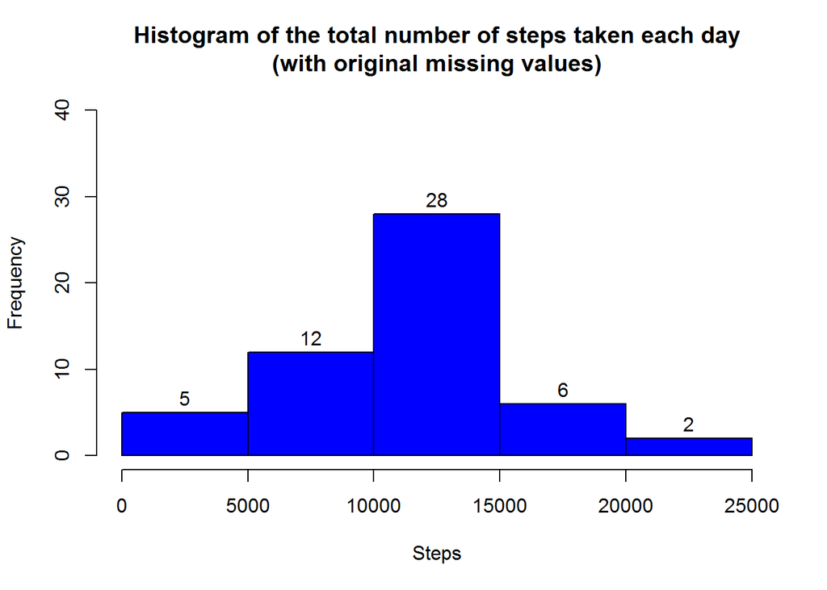

```r
hist(data.agg$steps, col="blue", main="Histogram of the total number of steps taken each day\n(with original missing values)", xlab="Steps", labels=TRUE, ylim = c(0, 40))
```

```r
dev.copy(png, file = "./figures/Figure1.png")     ## Copy plot to a PNG file
```

```r
dev.off()  ## Don't forget to close the PNG device!
```

and calculate the summary of the column steps:

```r
steps.sum <- summary(data.agg$steps)
steps.sum
```

```
##    Min. 1st Qu.  Median    Mean 3rd Qu.    Max.
##      41    8841   10760   10770   13290   21190
```

The mean of total number of steps taken per day is therefore 10770 and the median is 10760.

## What is the average daily activity pattern?

We calculate the mean number of steps across all days for each 5-minute interval using the functions *aggregate* and *mean* and see the structure of the resulting data frame:

```r
data.agg.5min <- aggregate(steps ~ interval, data = data, mean)
str(data.agg.5min)
```

```
## 'data.frame':    288 obs. of  2 variables:
##  $ interval: int  0 5 10 15 20 25 30 35 40 45 ...
##  $ steps   : num  1.717 0.3396 0.1321 0.1509 0.0755 ...
```

Then we plot the time series:

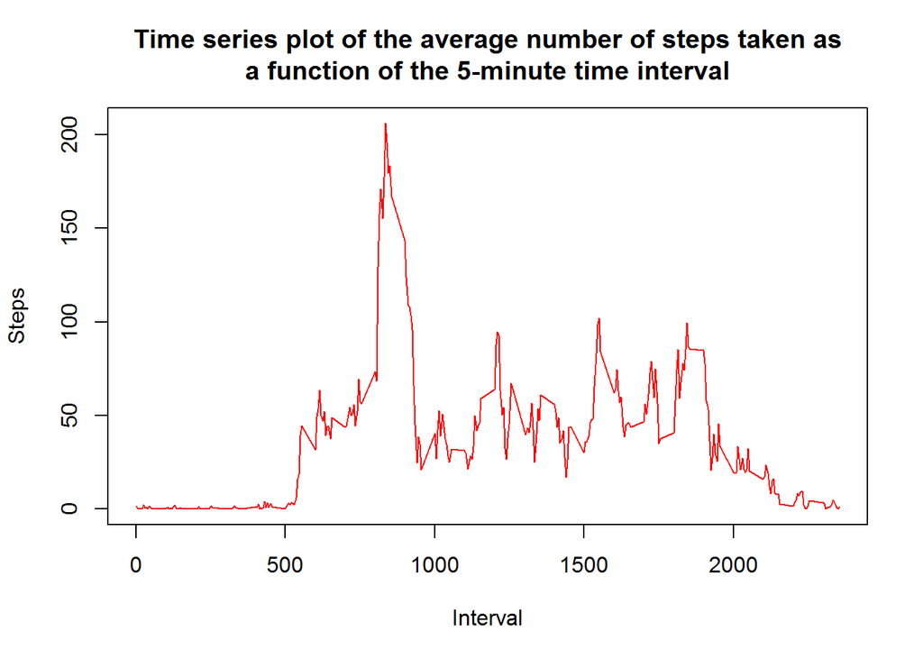

```r
plot(data.agg.5min$interval, data.agg.5min$steps, type = "l", col="red", main="Time series plot of the average number of steps taken as\na function of the 5-minute time interval", xlab="Interval", ylab="Steps")
```

```r
dev.copy(png, file = "./figures/Figure2.png")     ## Copy plot to a PNG file
```

```r
dev.off()  ## Don't forget to close the PNG device!
```

We search for a 5-minute interval, which contains the maximum number of steps, as follows:

```r
interval.max <- data.agg.5min$interval[which.max(data.agg.5min$steps)]
```

The 5-minute interval 835 (i.e. at 8:35 AM) contains the maximum number of steps, that is, 206 steps.

## Imputing missing values

We calculate the number of missing values in the dataset, as follows:

```r
missing <- sum(is.na(data$steps))
```

```r
tab.miss <- table(data[is.na(data$steps),c(1,2)], useNA = "ifany")
tab.miss
```

```
##       date
## steps  2012-10-01 2012-10-08 2012-11-01 2012-11-04 2012-11-09 2012-11-10
##   <NA>        288        288        288        288        288        288
##       date
## steps  2012-11-14 2012-11-30
##   <NA>        288        288
```

The total number of missing values is 2304. We have 8 days where the data are completely missing. We choose a strategy to fill all the missing values in the dataset with the mean of each 5-minute interval. First we check if we have available the means for all intervals:

```r
miss.agg <- sum(is.na(data.agg.5min$steps))
```

The number of missing means is 0. All the means are therefore available.

```r
data.filled <- merge(data,data.agg.5min, by = "interval", all = TRUE,
                     suffixes = c("",".mean"))
data.filled <- data.filled[ order(data.filled[,"date"],
                                  data.filled[,"interval"]), ]
data.filled[is.na(data.filled$steps),"steps"] <-
        data.filled[is.na(data.filled$steps),"steps.mean"]
```

Check missing values again:

```r
sum(is.na(data.filled$steps))
```

```
## [1] 0
```

There are no missing values. We aggregate the data in a similar manner as above and present them in the form of a histogram:

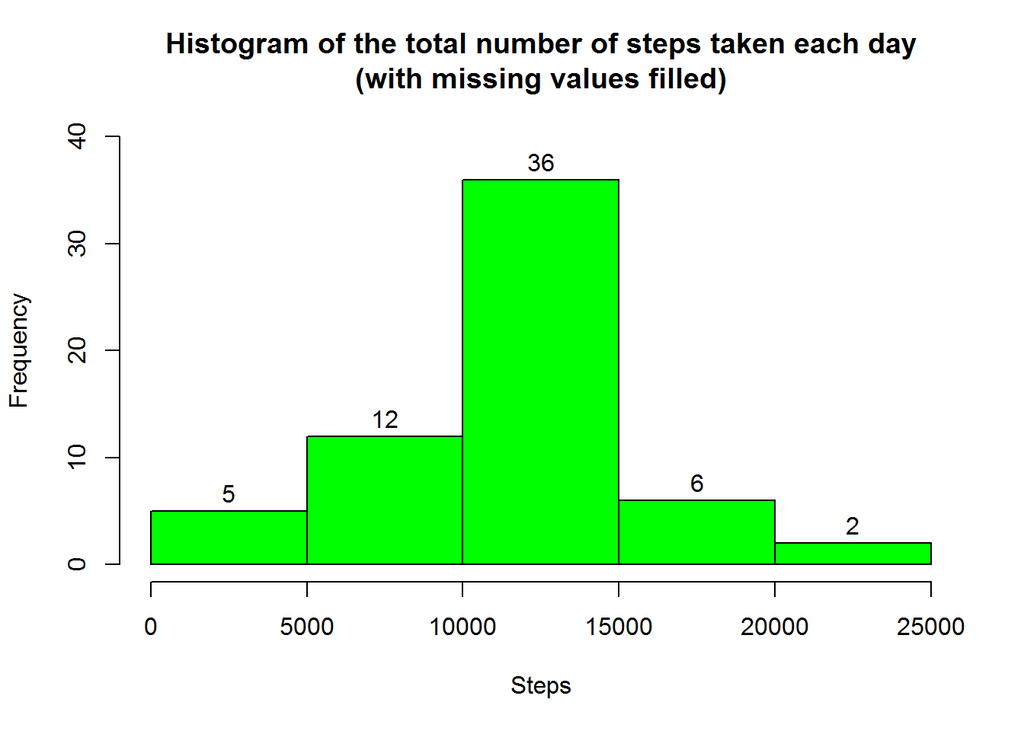

```r
data.filled.agg <- aggregate(steps ~ date, data = data.filled, sum)
hist(data.filled.agg$steps, col="green", main="Histogram of the total number of steps taken each day\n(with missing values filled)", xlab="Steps", labels=TRUE, ylim = c(0, 40))
```

```r
dev.copy(png, file = "./figures/Figure3.png")     ## Copy plot to a PNG file
```

```r
dev.off()  ## Don't forget to close the PNG device!
```

and calculate the their summary:

```r
steps.filled.sum <- summary(data.filled.agg$steps)
steps.filled.sum
```

```
##    Min. 1st Qu.  Median    Mean 3rd Qu.    Max.
##      41    9819   10770   10770   12810   21190
```

The mean of total number of steps taken per day is now 10770 and the median is 10770. The mean is the same as in the first case. The median is now equal to the mean (10770) comparing to the median in the first case(10760). In this case, imputing the missing values adds 8 days of missing data in the highest column of the histogram.